# nmer_OriginalHomeworkCode_02

Nicole Merullo

2023-09-28

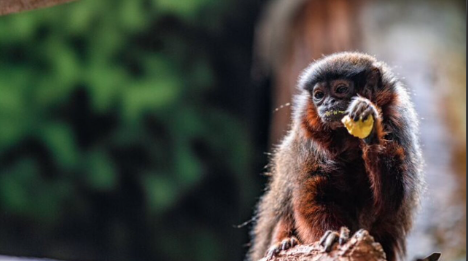

Cinnamon, the titi monkey from the Denver Zoo

# Challenges

1. I first tried to use in line html code to insert the titi monkey photo but could not quite crack that. Eventually I found a way to load in the image in a code chunk and I liked the way that looked and was able to center it easily.
2. I tried using library(prettydoc) to load in the html themes for the markdown (with include=FALSE in the chunk so it wouldn’t show up in the knitted html) but that returned an error when knitting because the output was being read before the library command was being read later on down in the file. I used the R Markdown Definitive Guide to format the YAML for the prettydoc themes and table of contents.
3. At first, I was having trouble translating the previous examples of the poisson distribution to the first question. The previous examples gave ranges for x but the first question didn’t have an upper limit and this stumped me! I decided to use the PMF and plug in the values to start with at least just getting the probability of 8 calls in one session (which led to challenge 4…).
4. When I used hte PMF, I kept getting a number greater than 1, which meant it wasn’t a probability (a vlue between 0 and 1). I think I was getting something like 21. I kept checking it over and over and thought I had it right. Eventually I asked Jimmy to check my work and even he thought it looked okay at FIRST, but when we looked at it again he realized I had switched the x and the lambda values in the exp() command. When I ran it again the right way around, it worked.
5. This still didn’t solve the problem though that I only had exactly 8 calls and not greater than 8 calls. I thought maybe I could do the complement (1-P(8)) of the probability of exactly 8 calls, but talking this through with Jimmy, he pointed out that I would return EVERYTHING above and below 8 calls. What I really needed was the right part of the plot after 8 (visualizing in my mind). I looked at the documentation for ppois() and saw that the argument lower.tail = FALSE returns the probability of X > x (not equal to!).

# Homework 2

Every Saturday, at the same time, a primatologist goes and sits in the forest in the morning and listens for titi monkey calls, counting the number of calls they hear in a 2 hour window from 5am to 7am. Based on previous knowledge, she believes that the mean number calls she will hear in that time is exactly 15. Let X represent the appropriate Poisson random variable of the number of calls heard in each monitoring session.

**Poisson Distribution: f(x)=((l^x)(exp(-l)))/(factorial(x))**

## >8 Calls

What is the probability that she will hear more than 8 calls during any given session?

```r
l <- 15
Peight <- ((l^8)*exp(-l))/factorial(8)
Peight
```

```
## [1] 0.0194443
```

```r
#this is for exactly 8 but need to know more than 8
ppois(8, l, lower.tail = FALSE) # This is more than 8
```

```
## [1] 0.9625535
```

The probability of just 8 is pretty small, but the probability of more than 8 is very high and this makes sense as this is apporaching the mean and inclusive of anything higher than that.

## 0 Calls

What is the probability that she will hear no calls in a session?

```r
PZero <- ((l^0)*exp(-l))/factorial(0)
PZero #really small approaching zero
```

```
## [1] 3.059023e-07
```

Again tthis makes sense because poisson distributions tend to have right skew and having zero calls in a session would be extremely unlikely!

## 3 Calls

What is the probability that she will hear exactly 3 calls in a session?

```r
PThree <- ((l^3)*exp(-l))/factorial(3)
PThree
```

```
## [1] 0.0001720701
```

This number is a little bigger than the probability of 0 calls in a session but it is still approaching 0.

## Plotting the PMF 0-30

Plot the relevant Poisson mass function over the values in range 0 ≤ x ≤ 30.

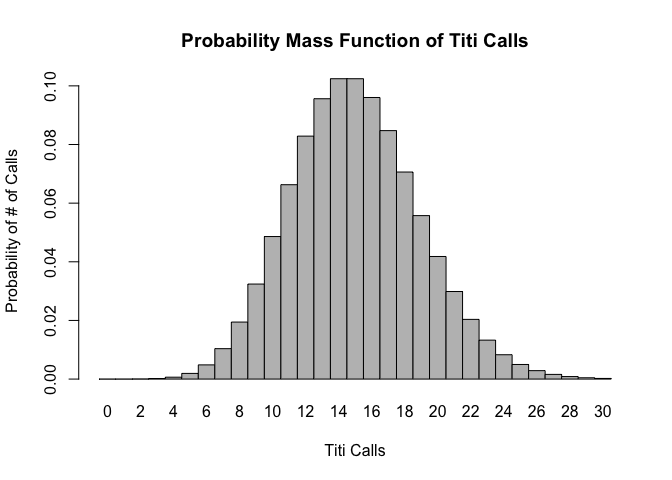

```r
x <- 0:30
calls <- dpois(x = x, lambda = l)
barplot(calls, names.arg = x, space = 0, xlab = "Titi Calls",
        ylab = "Probability of # of Calls",
        main = "Probability Mass Function of Titi Calls")
```

This plot reflects some of the results we got above - 0 calls isn’t even visible on here, 3 calls is barely visible above zero. Anything over 8 is most of the probability.

## Simulate 104 Mornings

Simulate 104 results from this distribution (i.e., 2 years of Saturday monitoring sessions).

```r
mornings <- 104
years <- rpois(mornings, l)
years
```

```
##   [1] 14 23 17 16 16 16 17 16  8 15 11 13 11 20 14 15 14 13 16 18 14 16 16 18 17
##  [26] 11 18 21 11 11 15 22 12 11 20  9 13 18 10 17 20  9 22 13  9 15 10 13  8 10
##  [51] 14 12 18 16 11  8 20 18 13 21 16 11 11 16 18  7 13 19 11 13 15 19 17 15 10
##  [76] 11  8 13 14 16 12 19 16 16 13 13 18 16 14 14 14 11 17 16 13 17 12 14 12 14
## [101] 21 16 12 10
```

The years variable contains simulated numbers titi calls over 104 mornings (given the mean is 15).

## Plot a Histogram

Plot the simulated results using hist() and use xlim() to set the horizontal limits to be from 0 to 30. How does your histogram compare to the shape of the probability mass function you plotted above?

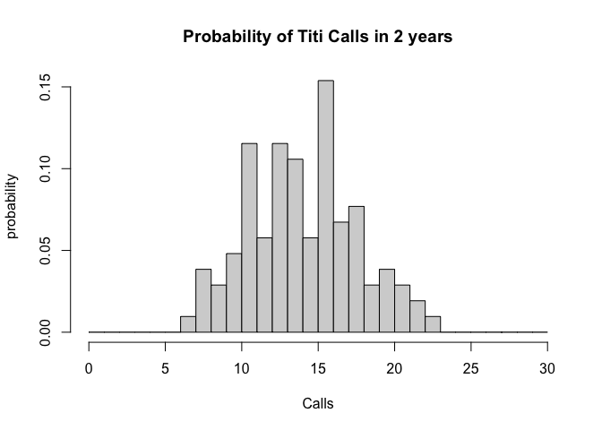

```r
hist(years, breaks = c(0:30), probability = TRUE,
     main = "Probability of Titi Calls in 2 years",
     xlab = "Calls", ylab = "probability", xlim = range(0:30))
```

The histogram peaks close to the average (lambda value) at 15 and has right skew like the pmf. However, it is more varied because the numbers were random.